# Souvenir Sales Forecast

Siva Bulusu

14/12/2019

Sales of souvenir data has been provided in the fancy.dat files.It contains monthly sales for a souvenir shop at a beach resort town in Queensland, Australia, for January 1987-December 1993.We are going to predict the sales for next 5 years.

Load required libraries.

```r
library(forecast)
library(xts)
library(ggfortify)
library(tseries)
library(readr)
library(dplyr)
```

```r
library(ggplot2)
```

Set working directory.

```r
setwd("D:/SivaBulusu/SouvenirSalesForecast")
getwd()
```

```
## [1] "D:/SivaBulusu/SouvenirSalesForecast"
```

Read the dataset and view it.

```r
souvenir.data <- read.table("fancy-1.txt", header = FALSE, sep="", as.is=TRUE)
View(souvenir.data)
```

There are 84 values. As per given inputs the data is from January 1987 to December 1993. 7 years in total. That is 7*12 = 84 months. So missing values are not there which is good.

Check the structure of given data.

```r
class(souvenir.data)
```

```
## [1] "data.frame"
```

```r
str(souvenir.data)
```

```
## 'data.frame':    84 obs. of  1 variable:
##  $ V1: num  1665 2398 2841 3547 3753 ...
```

The data given is not in time series format. So we need to convert the data in to time series.

Convert the data frame into time series and check the format.

```r
souvenir.data.ts <- ts(souvenir.data,start = c(1987,1),end = c(1993,12),frequency = 12)
class(souvenir.data.ts)
```

```
## [1] "ts"
```

The data is now converted to time series.

Check if the data is converted properly by seeing the start, end, frequency and periodicity.

```r
start(souvenir.data.ts)
```

```
## [1] 1987    1
```

```r
end(souvenir.data.ts)
```

```
## [1] 1993   12
```

```r
frequency(souvenir.data.ts)
```

```
## [1] 12
```

```r
periodicity(souvenir.data.ts)
```

```
## Monthly periodicity from Jan 1987 to Dec 1993
```

```r
dim(souvenir.data.ts)
```

```
## [1] 84  1
```

```r
str(souvenir.data.ts)
```

```
##  Time-Series [1:84, 1] from 1987 to 1994: 1665 2398 2841 3547 3753 ...
##  - attr(*, "dimnames")=List of 2
##   ..$ : NULL
##   ..$ : chr "V1"
```

The time series is as per inputs. From January 1987 to December 1993 with monthly frequency.

Plot the dataset and see trend line.

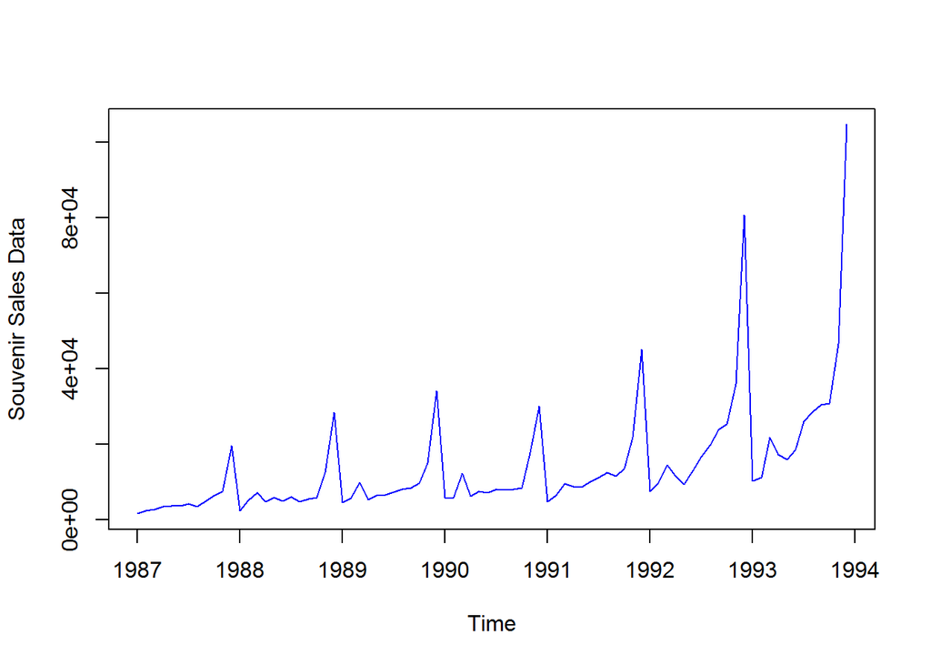

```r
plot(souvenir.data.ts,ylab="Souvenir Sales Data",col = "blue" ,pch=20)
```

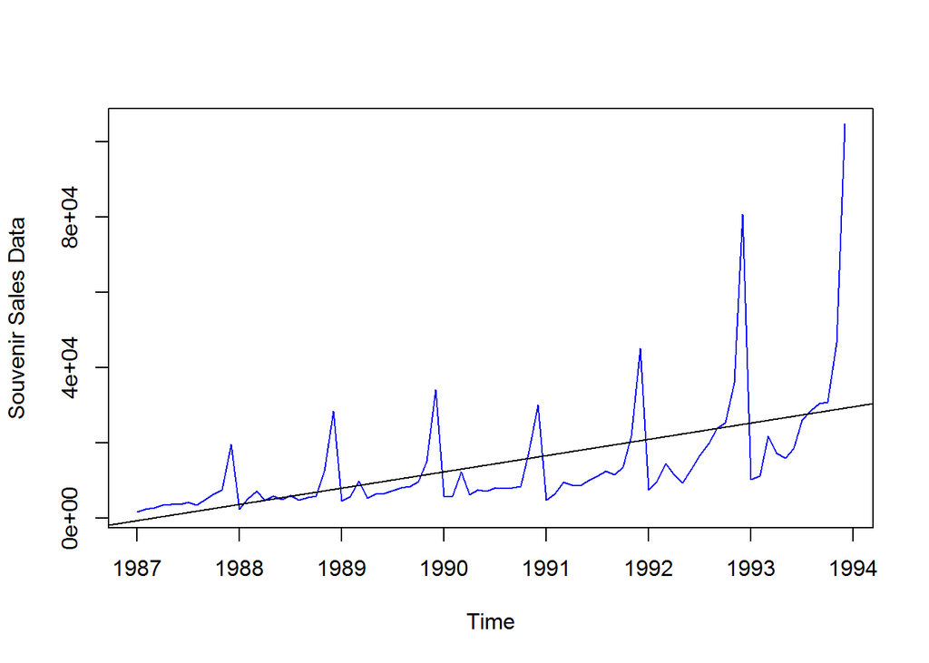

```r
plot(souvenir.data.ts,ylab="Souvenir Sales Data",col = "blue" ,pch=20)
abline(reg = lm(souvenir.data.ts~time(souvenir.data.ts)))
```

Little upward trend is observed along with seasonality.

Decompose the tie series and plot the graph.

```r
souvenir.data.ts.decompM <- decompose(souvenir.data.ts,type = "multiplicative")
souvenir.data.ts.decompM
```

```
## $x
##            Jan       Feb       Mar       Apr       May       Jun       Jul
## 1987   1664.81   2397.53   2840.71   3547.29   3752.96   3714.74   4349.61
## 1988   2499.81   5198.24   7225.14   4806.03   5900.88   4951.34   6179.12
## 1989   4717.02   5702.63   9957.58   5304.78   6492.43   6630.80   7349.62
## 1990   5921.10   5814.58  12421.25   6369.77   7609.12   7224.75   8121.22
## 1991   4826.64   6470.23   9638.77   8821.17   8722.37  10209.48  11276.55
## 1992   7615.03   9849.69  14558.40  11587.33   9332.56  13082.09  16732.78
## 1993  10243.24  11266.88  21826.84  17357.33  15997.79  18601.53  26155.15
##            Aug       Sep       Oct       Nov       Dec
## 1987   3566.34   5021.82   6423.48   7600.60  19756.21
## 1988   4752.15   5496.43   5835.10  12600.08  28541.72
## 1989   8176.62   8573.17   9690.50  15151.84  34061.01
## 1990   7979.25   8093.06   8476.70  17914.66  30114.41
## 1991  12552.22  11637.39  13606.89  21822.11  45060.69
```

[output cut: 66 more lines]

Plot decomposed time series.

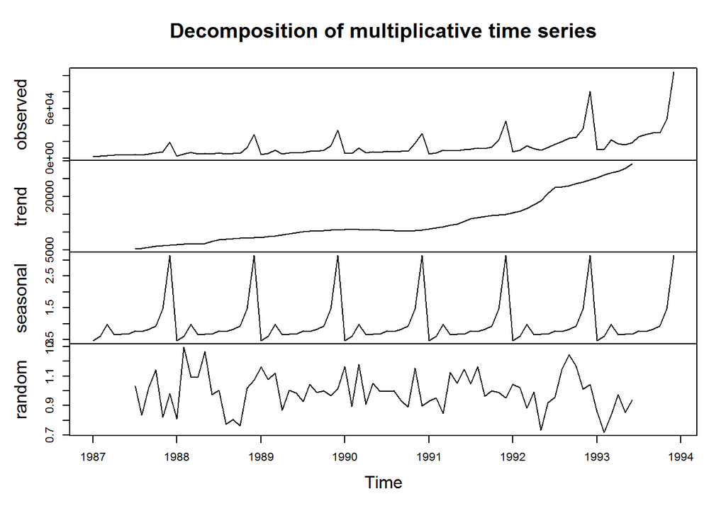

```r
plot(souvenir.data.ts.decompM,ylab="Decomposed Time Series",pch=20)
```

Upward trend over a period of time and seasonality through out the period are observed.

Check the seasonal component of given time series and plot the series.

```r
souvenir.data.ts.decompM$seasonal
```

```
##            Jan       Feb       Mar       Apr       May       Jun       Jul
## 1987 0.4745416 0.6042447 0.9828893 0.6568138 0.6748599 0.6793992 0.7778894
## 1988 0.4745416 0.6042447 0.9828893 0.6568138 0.6748599 0.6793992 0.7778894
## 1989 0.4745416 0.6042447 0.9828893 0.6568138 0.6748599 0.6793992 0.7778894
## 1990 0.4745416 0.6042447 0.9828893 0.6568138 0.6748599 0.6793992 0.7778894
## 1991 0.4745416 0.6042447 0.9828893 0.6568138 0.6748599 0.6793992 0.7778894
## 1992 0.4745416 0.6042447 0.9828893 0.6568138 0.6748599 0.6793992 0.7778894
## 1993 0.4745416 0.6042447 0.9828893 0.6568138 0.6748599 0.6793992 0.7778894
##            Aug       Sep       Oct       Nov       Dec
## 1987 0.7649696 0.8356251 0.9217051 1.4797541 3.1473083
## 1988 0.7649696 0.8356251 0.9217051 1.4797541 3.1473083
## 1989 0.7649696 0.8356251 0.9217051 1.4797541 3.1473083
## 1990 0.7649696 0.8356251 0.9217051 1.4797541 3.1473083
## 1991 0.7649696 0.8356251 0.9217051 1.4797541 3.1473083
## 1992 0.7649696 0.8356251 0.9217051 1.4797541 3.1473083
## 1993 0.7649696 0.8356251 0.9217051 1.4797541 3.1473083
```

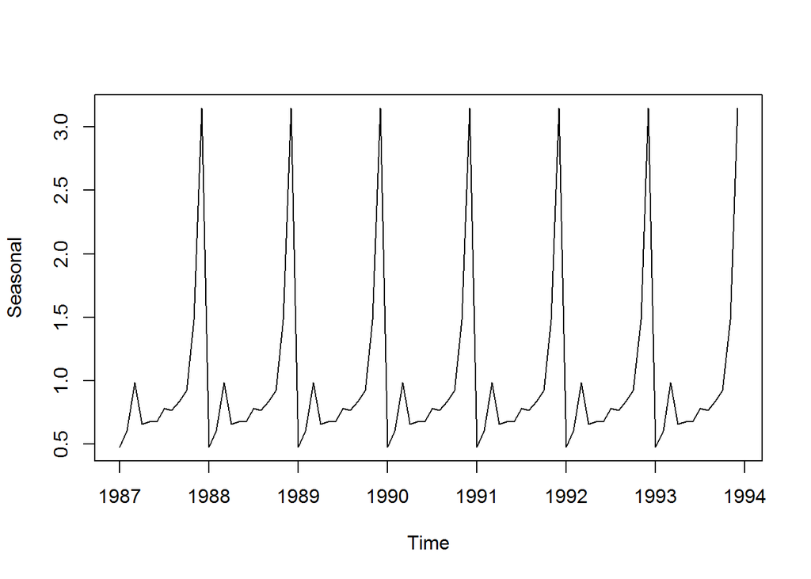

```r
plot(souvenir.data.ts.decompM$seasonal,ylab="Seasonal",pch=20)
```

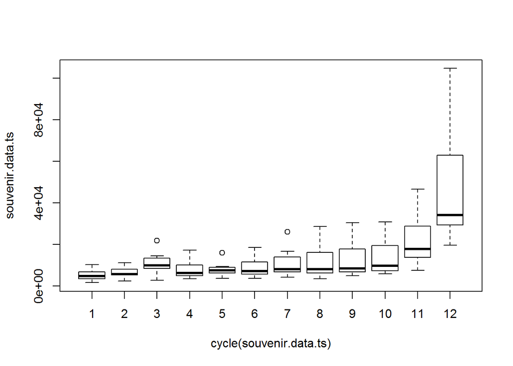

```r
boxplot(souvenir.data.ts~cycle(souvenir.data.ts))
```

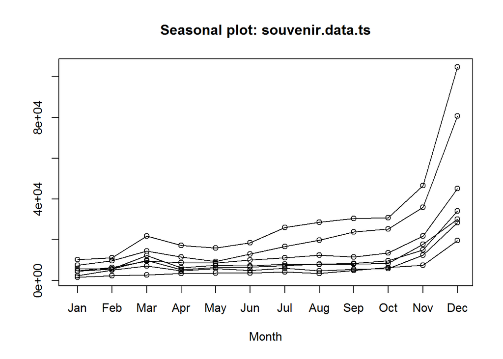

```r
seasonplot(souvenir.data.ts)
```

Plot the trend component.

```r
souvenir.data.ts.decompM$trend
```

```
##            Jan       Feb       Mar       Apr       May       Jun       Jul
## 1987        NA        NA        NA        NA        NA        NA  5421.133
## 1988  6517.855  6643.493  6712.677  6707.937  6891.732  7466.107  7924.554
## 1989  8566.257  8757.715  9028.598  9317.438  9584.403  9920.696 10200.837
## 1990 10729.094 10753.020 10724.792 10654.212 10718.755 10669.431 10459.387
## 1991 10913.802 11235.815 11574.035 11935.474 12312.042 13097.614 13836.559
## 1992 15392.422 15925.448 16743.464 17746.816 18829.614 20907.268 22502.653
## 1993 25224.785 25979.797 26616.045 27116.128 27784.443 29223.966        NA
##            Aug       Sep       Oct       Nov       Dec
## 1987  5572.621  5872.002  6107.134  6249.078  6390.100
## 1988  8037.954  8172.822  8307.455  8352.884  8447.509
## 1989 10255.671 10362.989 10510.016 10600.920 10672.196
## 1990 10441.103 10352.485 10338.690 10487.217 10657.966
## 1991 14093.552 14439.348 14759.589 14900.270 15045.387
## 1992 22671.211 23033.112 23576.381 24094.515 24602.210
## 1993        NA        NA        NA        NA        NA
```

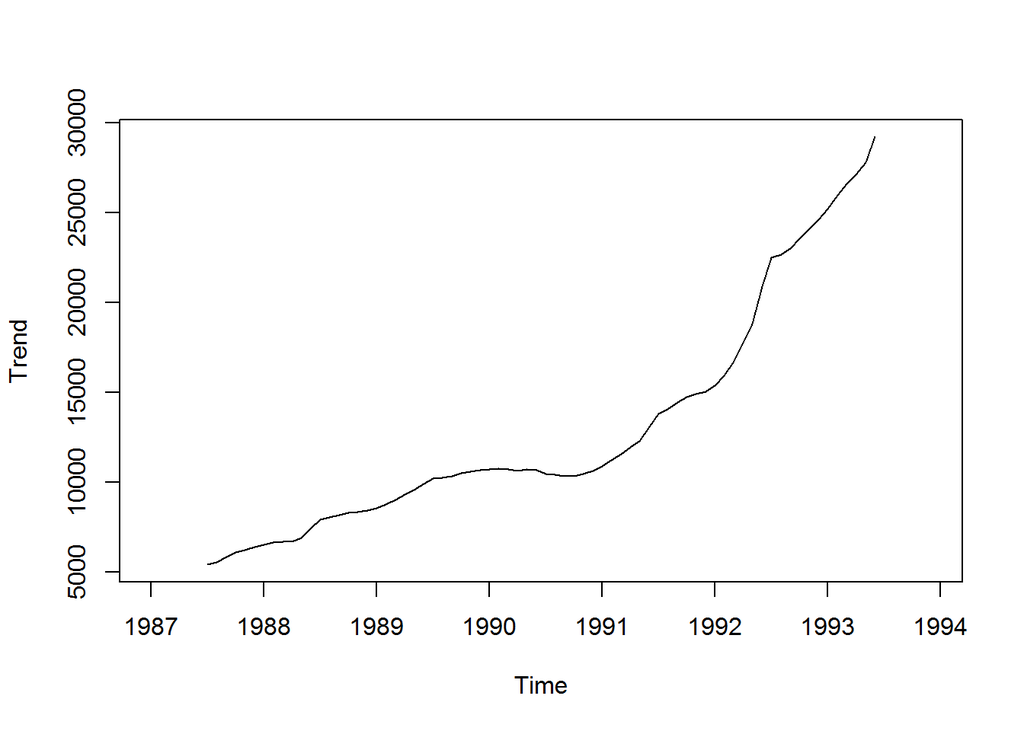

```r
plot(souvenir.data.ts.decompM$trend,ylab="Trend",pch=20)
```

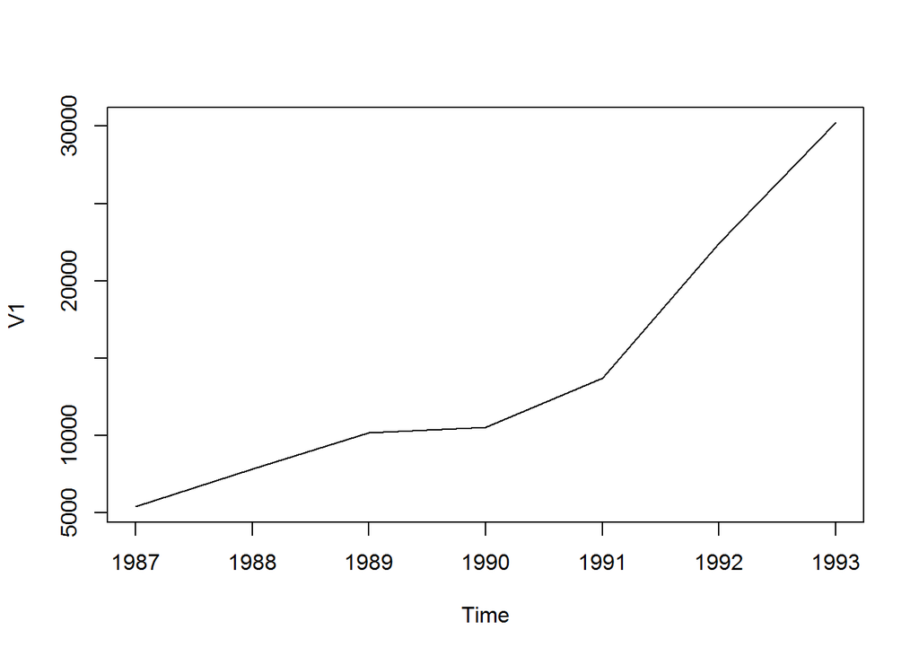

```r
#Aggregate the cycles and display a year on year trend
plot(aggregate(souvenir.data.ts,FUN=mean))
```

Upward Trend is observed throughout the period.

Plot the random component.

```r
souvenir.data.ts.decompM$random
```

```
##            Jan       Feb       Mar       Apr       May       Jun       Jul
## 1987        NA        NA        NA        NA        NA        NA 1.0314363
## 1988 0.8082172 1.2949322 1.0950801 1.0908255 1.2687462 0.9761207 1.0023837
## 1989 1.1603856 1.0776347 1.1220930 0.8668195 1.0037571 0.9837817 0.9262138
## 1990 1.1629608 0.8949011 1.1783432 0.9102489 1.0519049 0.9966818 0.9981532
## 1991 0.9319542 0.9530207 0.8472902 1.1252377 1.0497619 1.1473249 1.0476840
## 1992 1.0425344 1.0235712 0.8846342 0.9940785 0.7344221 0.9209898 0.9559090
## 1993 0.8557277 0.7177201 0.8343393 0.9745699 0.8531879 0.9368811        NA
##            Aug       Sep       Oct       Nov       Dec
## 1987 0.8366022 1.0234425 1.1411453 0.8219442 0.9823284
## 1988 0.7728593 0.8048171 0.7620586 1.0194063 1.0735251
## 1989 1.0422347 0.9900222 1.0003473 0.9659003 1.0140618
## 1990 0.9990138 0.9355277 0.8895479 1.1544065 0.8977610
## 1991 1.1642758 0.9644873 1.0002133 0.9897216 0.9516016
## 1992 1.1467942 1.2434832 1.1684676 1.0104011 1.0425021
## 1993        NA        NA        NA        NA        NA
```

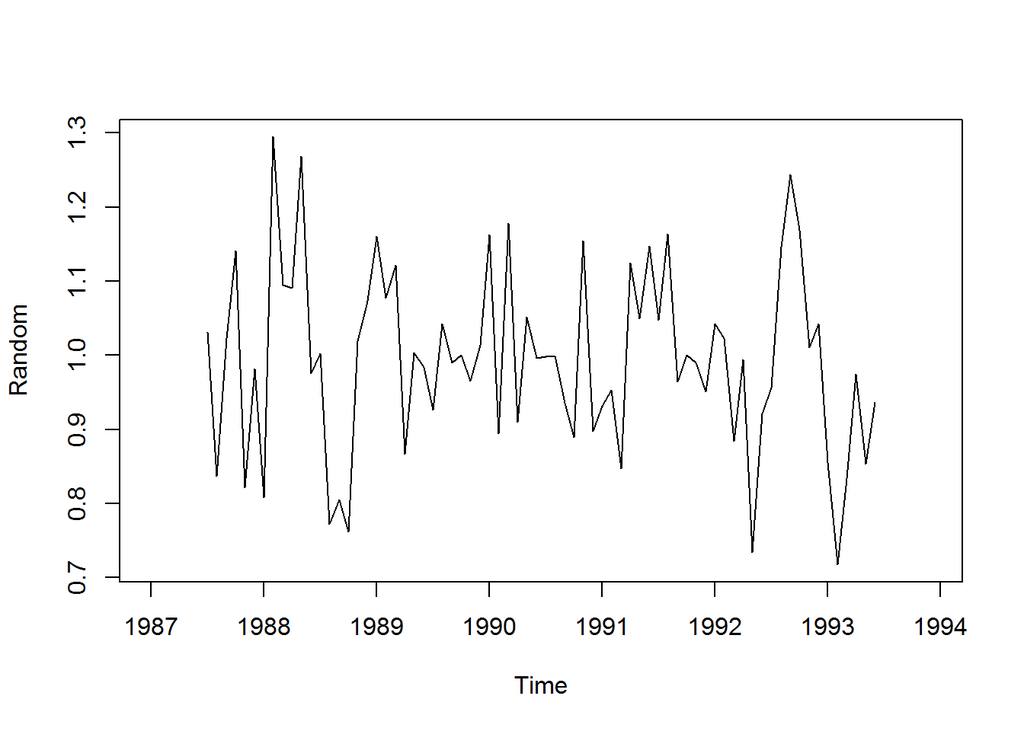

```r
plot(souvenir.data.ts.decompM$random,ylab="Random",pch=20)
```

Check for stationarity in the given time series.

ADF Test Null Hypothesis(H0): The series has a unit root (value of a =1) Alternate Hypothesis(H1): The series has no unit root.

KPSS Test Null Hypothesis(H0): The data is stationary. Alternate Hypothesis(H1): The data is not stationary.

```r
adf.test(souvenir.data.ts)
```

```
##
##  Augmented Dickey-Fuller Test
##
## data:  souvenir.data.ts
## Dickey-Fuller = -2.0809, Lag order = 4, p-value = 0.5427
## alternative hypothesis: stationary
```

```r
kpss.test(souvenir.data.ts)
```

```
##
##  KPSS Test for Level Stationarity
##
## data:  souvenir.data.ts
## KPSS Level = 1.3089, Truncation lag parameter = 3, p-value = 0.01
```

Based on the p-value in both the tests the given data is non-stationary.

Do log and check stationarity

```r
salesLog <- log(souvenir.data.ts)
```

Check the values using log function. ADF Test Null Hypothesis(H0): The series has a unit root (value of a =1) Alternate Hypothesis(H1): The series has no unit root.

KPSS Test Null Hypothesis(H0): The data is stationary. Alternate Hypothesis(H1): The data is not stationary.

```r
adf.test(salesLog)
```

```
##
##  Augmented Dickey-Fuller Test
##
## data:  salesLog
## Dickey-Fuller = -3.7361, Lag order = 4, p-value = 0.02654
## alternative hypothesis: stationary
```

```r
kpss.test(salesLog)
```

```
##
##  KPSS Test for Level Stationarity
##
## data:  salesLog
## KPSS Level = 1.7909, Truncation lag parameter = 3, p-value = 0.01
```

Based on ADF test the time series became stationary after using log function.

## Holts-Winter Model

Use log function for making data stationary and build Holts-Winter model.

```r
salesLog <- log(souvenir.data.ts)
salesLogHW <- HoltWinters(salesLog)
salesLogHW
```

```
## Holt-Winters exponential smoothing with trend and additive seasonal component.
##
## Call:
## HoltWinters(x = salesLog)
##
## Smoothing parameters:
##  alpha: 0.413418
##  beta : 0
##  gamma: 0.9561275
##
## Coefficients:
##            [,1]
## a   10.37661961
## b    0.02996319
## s1  -0.80952063
## s2  -0.60576477
## s3   0.01103238
## s4  -0.24160551
## s5  -0.35933517
## s6  -0.18076683
## s7   0.07788605
## s8   0.10147055
## s9   0.09649353
## s10  0.05197826
## s11  0.41793637
## s12  1.18088423
```

Forecast for next 5 years using above model and measure the accuracy.

```r
next5YearSalesFcLogHW <- forecast(salesLogHW, h=60)
next5YearSalesFcLogHW
```

```
##          Point Forecast     Lo 80     Hi 80     Lo 95     Hi 95
## Jan 1994       9.597062  9.381514  9.812611  9.267409  9.926715
## Feb 1994       9.830781  9.597539 10.064024  9.474068 10.187495
## Mar 1994      10.477542 10.227856 10.727227 10.095680 10.859403
## Apr 1994      10.254867  9.989756 10.519978  9.849415 10.660319
## May 1994      10.167100  9.887413 10.446787  9.739356 10.594845
## Jun 1994      10.375632 10.082092 10.669172  9.926701 10.824562
## Jul 1994      10.664248 10.357480 10.971016 10.195087 11.133409
## Aug 1994      10.717796 10.398347 11.037244 10.229241 11.206350
## Sep 1994      10.742782 10.411137 11.074427 10.235575 11.249989
## Oct 1994      10.728230 10.384822 11.071638 10.203032 11.253427
## Nov 1994      11.124151 10.769369 11.478933 10.581559 11.666743
## Dec 1994      11.917062 11.551260 12.282864 11.357616 12.476508
## Jan 1995       9.956620  9.534825 10.378416  9.311540 10.601701
## Feb 1995      10.190339  9.759233 10.621446  9.531020 10.849659
## Mar 1995      10.837100 10.396880 11.277319 10.163842 11.510358
## Apr 1995      10.614425 10.165277 11.063573  9.927512 11.301338
## May 1995      10.526659 10.068756 10.984562  9.826356 11.226961
## Jun 1995      10.735190 10.268697 11.201684 10.021750 11.448630
## Jul 1995      11.023806 10.548878 11.498735 10.297466 11.750146
## Aug 1995      11.077354 10.594138 11.560570 10.338339 11.816369
## Sep 1995      11.102340 10.610976 11.593704 10.350863 11.853817
## Oct 1995      11.087788 10.588409 11.587167 10.324053 11.851523
## Nov 1995      11.483709 10.976442 11.990977 10.707910 12.259508
## Dec 1995      12.276620 11.761585 12.791656 11.488942 13.064299
## Jan 1996      10.316179  9.759975 10.872382  9.465539 11.166818
## Feb 1996      10.549898  9.986601 11.113194  9.688410 11.411385
## Mar 1996      11.196658 10.626357 11.766960 10.324457 12.068859
## Apr 1996      10.973983 10.396762 11.551205 10.091199 11.856767
## May 1996      10.886217 10.302157 11.470276  9.992975 11.779459
## Jun 1996      11.094748 10.503930 11.685567 10.191170 11.998327
## Jul 1996      11.383364 10.785864 11.980865 10.469566 12.297163
## Aug 1996      11.436912 10.832803 12.041022 10.513006 12.360818
## Sep 1996      11.461898 10.851252 12.072545 10.527995 12.395802
## Oct 1996      11.447346 10.830232 12.064460 10.503551 12.391141
## Nov 1996      11.843268 11.219753 12.466782 10.889684 12.796851
## Dec 1996      12.636179 12.006328 13.266029 11.672905 13.599452
## Jan 1997      10.675737 10.011800 11.339674  9.660333 11.691141
## Feb 1997      10.909456 10.239565 11.579346  9.884947 11.933965
## Mar 1997      11.556216 10.880425 12.232008 10.522682 12.589750
## Apr 1997      11.333542 10.651900 12.015183 10.291061 12.376022
## May 1997      11.245775 10.558334 11.933217 10.194424 12.297126
## Jun 1997      11.454307 10.761113 12.147500 10.394159 12.514454
## Jul 1997      11.742923 11.044025 12.441820 10.674051 12.811794
## Aug 1997      11.796470 11.091915 12.501026 10.718946 12.873995
## Sep 1997      11.821457 11.111288 12.531625 10.735347 12.907566
## Oct 1997      11.806904 11.091167 12.522642 10.712278 12.901531
## Nov 1997      12.202826 11.481562 12.924089 11.099748 13.305903
## Dec 1997      12.995737 12.268989 13.722485 11.884272 14.107202
## Jan 1998      11.035295 10.278815 11.791776  9.878358 12.192232
## Feb 1998      11.269014 10.507303 12.030725 10.104078 12.433951
## Mar 1998      11.915775 11.148869 12.682680 10.742893 13.088656
## Apr 1998      11.693100 10.921034 12.465166 10.512327 12.873872
## May 1998      11.605333 10.828142 12.382525 10.416722 12.793945
## Jun 1998      11.813865 11.031582 12.596148 10.617466 13.010264
## Jul 1998      12.102481 11.315139 12.889823 10.898345 13.306617
## Aug 1998      12.156029 11.363659 12.948398 10.944204 13.367853
## Sep 1998      12.181015 11.383650 12.978379 10.961551 13.400478
## Oct 1998      12.166463 11.364134 12.968791 10.939407 13.393518
## Nov 1998      12.562384 11.755122 13.369646 11.327784 13.796985
## Dec 1998      13.355295 12.543130 14.167460 12.113195 14.597395
```

```r
class(next5YearSalesFcLogHW)
```

```
## [1] "forecast"
```

```r
accuracy(next5YearSalesFcLogHW)
```

```
##                        ME      RMSE       MAE         MPE     MAPE      MASE
## Training set -0.006421623 0.1671448 0.1278046 -0.08896552 1.385112 0.4077539
##                    ACF1
## Training set 0.04525314
```

MAPE is 1.38 for this model.

Use diff log function for making data stationary and build Holts-Winter model.

```r
salesdiffLog <- diff(log(souvenir.data.ts))
salesDiffLogHW <- HoltWinters(salesdiffLog)
salesDiffLogHW
```

```
## Holt-Winters exponential smoothing with trend and additive seasonal component.
##
## Call:
## HoltWinters(x = salesdiffLog)
##
## Smoothing parameters:
##  alpha: 0.003857349
##  beta : 1
##  gamma: 0.6960774
##
## Coefficients:
##              [,1]
## a   -0.0139852509
## b    0.0003217676
## s1  -1.9561297136
## s2   0.1669637709
## s3   0.6116380755
## s4  -0.2080554491
## s5  -0.0754660986
## s6   0.2072229774
## s7   0.3201844682
## s8   0.1250578484
## s9   0.0997683847
## s10  0.0501979844
## s11  0.4295295923
## s12  0.8146669164
```

Forecast for next 5 years using above model and measure the accuracy.

```r
next5YearSalesFcDiffLogHW <- forecast(salesDiffLogHW, h=60)
next5YearSalesFcDiffLogHW
```

```
##          Point Forecast        Lo 80       Hi 80        Lo 95      Hi 95
## Jan 1994    -1.96979320 -2.218693997 -1.72089240 -2.350454121 -1.5891323
## Feb 1994     0.15362206 -0.095286151  0.40253026 -0.227050197  0.5342943
## Mar 1994     0.59861813  0.349693256  0.84754300  0.217920390  0.9793159
## Apr 1994    -0.22075363 -0.469708123  0.02820086 -0.601496672  0.1599894
## May 1994    -0.08784251 -0.336843284  0.16115826 -0.468656331  0.2929713
## Jun 1994     0.19516833 -0.053899066  0.44423573 -0.185747383  0.5760840
## Jul 1994     0.30845159  0.059293535  0.55760965 -0.072602772  0.6895060
## Aug 1994     0.11364674 -0.135629676  0.36292315 -0.267588639  0.4948821
## Sep 1994     0.08867904 -0.160747090  0.33810517 -0.292785309  0.4701434
## Oct 1994     0.03943041 -0.210180436  0.28904126 -0.342316436  0.4211773
## Nov 1994     0.41908379  0.169249619  0.66891795  0.036995400  0.8011722
## Dec 1994     0.80454288  0.554443201  1.05464255  0.422048430  1.1870373
## Jan 1995    -1.96593199 -2.277058499 -1.65480547 -2.441758926 -1.4901050
## Feb 1995     0.15748327 -0.153933460  0.46889999 -0.318787517  0.6337540
## Mar 1995     0.60247934  0.290729793  0.91422888  0.125699552  1.0792591
## Apr 1995    -0.21689242 -0.529020208  0.09523537 -0.694250679  0.2604658
## May 1995    -0.08398130 -0.396535541  0.22857294 -0.561991761  0.3940292
## Jun 1995     0.19902954 -0.114002104  0.51206119 -0.279711049  0.6777701
## Jul 1995     0.31231280 -0.001249915  0.62587552 -0.167239991  0.7918656
## Aug 1995     0.11750795 -0.196642161  0.43165806 -0.362943185  0.5979591
## Sep 1995     0.09254025 -0.222256189  0.40733670 -0.388899359  0.5739799
## Oct 1995     0.04329162 -0.272212650  0.35879589 -0.439230523  0.5258138
## Nov 1995     0.42294500  0.106668898  0.73922109 -0.060757555  0.9066475
## Dec 1995     0.80840409  0.491289724  1.12551845  0.323419520  1.2933887
## Jan 1996    -1.96207077 -2.335177323 -1.58896423 -2.532687999 -1.3914536
## Feb 1996     0.16134448 -0.212596192  0.53528515 -0.410548425  0.7332374
## Mar 1996     0.60634055  0.231502442  0.98117866  0.033075134  1.1796060
## Apr 1996    -0.21303121 -0.588832069  0.16276965 -0.787769029  0.3617066
## May 1996    -0.08012009 -0.456950967  0.29671079 -0.656433184  0.4961930
## Jun 1996     0.20289075 -0.175039291  0.58082080 -0.375103371  0.7808849
## Jul 1996     0.31617401 -0.062926180  0.69527421 -0.263609699  0.8959577
## Aug 1996     0.12136916 -0.258973929  0.50171225 -0.460315399  0.7030537
## Sep 1996     0.09640146 -0.285258976  0.47806191 -0.487297809  0.6801007
## Oct 1996     0.04715283 -0.335901051  0.43020672 -0.538677528  0.6329832
## Nov 1996     0.42680621  0.042281219  0.81133120 -0.161274014  1.0148864
## Dec 1996     0.81226530  0.426190044  1.19834055  0.221814150  1.4027164
## Jan 1997    -1.95820956 -2.396802394 -1.51961673 -2.628979414 -1.2874397
## Feb 1997     0.16520569 -0.274901947  0.60531332 -0.507880857  0.8382922
## Mar 1997     0.61020176  0.168504162  1.05189936 -0.065316424  1.2857199
## Apr 1997    -0.20917000 -0.652533987  0.23419399 -0.887236706  0.4688967
## May 1997    -0.07625888 -0.521366901  0.36884915 -0.756992855  0.6044751
## Jun 1997     0.20675197 -0.240178884  0.65368282 -0.476769784  0.8902737
## Jul 1997     0.32003522 -0.128798340  0.76886879 -0.366396477  1.0064669
## Aug 1997     0.12523037 -0.325586828  0.57604757 -0.564235038  0.8146958
## Sep 1997     0.10026268 -0.352620053  0.55314540 -0.592361688  0.7928870
## Oct 1997     0.05101404 -0.404017019  0.50604511 -0.644895913  0.7469240
## Nov 1997     0.43066742 -0.026595629  0.88793047 -0.268656065  1.1299909
## Dec 1997     0.81612651  0.356547037  1.27570598  0.113260360  1.5189927
## Jan 1998    -1.95434835 -2.463711609 -1.44498510 -2.733352229 -1.1753445
## Feb 1998     0.16906690 -0.342553462  0.68068726 -0.613388921  0.9515227
## Mar 1998     0.61406297  0.100104839  1.12802110 -0.171968161  1.4000941
## Apr 1998    -0.20530878 -0.721686044  0.31106847 -0.995039653  0.5844221
## May 1998    -0.07239767 -0.591276047  0.44648071 -0.865953670  0.7211583
## Jun 1998     0.21061318 -0.310848906  0.73207526 -0.586894259  1.0081206
## Jul 1998     0.32389644 -0.200232470  0.84802534 -0.477689553  1.1254824
## Aug 1998     0.12909158 -0.397787752  0.65597092 -0.676700824  0.9348840
## Sep 1998     0.10412389 -0.425589922  0.63383770 -0.706003474  0.9142512
## Oct 1998     0.05487525 -0.477757462  0.58750797 -0.759716190  0.8694667
## Nov 1998     0.43452863 -0.101107768  0.97016503 -0.384656549  1.2537138
## Dec 1998     0.81998772  0.281262575  1.35871287 -0.003921291  1.6438967
```

```r
accuracy(next5YearSalesFcDiffLogHW)
```

```
##                      ME      RMSE       MAE      MPE     MAPE      MASE
## Training set 0.01189455 0.1932122 0.1406016 33.61249 144.1483 0.8318766
##                    ACF1
## Training set -0.5123552
```

MAPE is 144.14

Compare the above two forecasts. And decide which model to use based on accuracy.

MAPE for next5YearSalesFcLogHW: 1.38 MAPE for next5YearSalesFcDiffLogHW: 144.14

First method has given better accuracy. So, let us use this forecast. However, the forecast has been done on log so they have to be converted to real values to get actual numbers for next 5 years.

Consider next5YearSalesFcLogHW which has higher accuracy and get the actual numbers for prediction. Write csv, read them and then apply exp function on the values. Bind the new column and create a new csv file with predicted values.

```r
#The forecasted values of souviner sales for the next five years
#The values are calculated at 80% and 95% confidence interval.
write.csv(next5YearSalesFcLogHW,file = "Next5YearsForecast_HoltsWinter_Log.csv")
logPred <- read.csv("Next5YearsForecast_HoltsWinter_Log.csv",header = TRUE)

#Get the real value by applying antilog.
#log function in R is natural logarithm with base e.
#So use exp function to get e power of value
realPred <- exp(logPred[2])
realPred
```

```
##    Point.Forecast
## 1        14721.47
## 2        18597.48
## 3        35509.00
## 4        28420.52
## 5        26032.48
## 6        32068.58
## 7        42798.06
## 8        45152.26
## 9        46294.66
## 10       45625.85
## 11       67788.72
## 12      149800.86
## 13       21091.39
## 14       26644.54
```

[output cut: 46 more lines]

```r
#Bind the prediictions column
next5years_prediction_HW <- cbind(logPred,realPred)

#Name the last column filled with predictions
names(next5years_prediction_HW)[7]<-"Predicted Value"

#See the predictions
next5years_prediction_HW
```

```
##           X Point.Forecast     Lo.80     Hi.80     Lo.95     Hi.95
## 1  Jan 1994       9.597062  9.381514  9.812611  9.267409  9.926715
## 2  Feb 1994       9.830781  9.597539 10.064024  9.474068 10.187495
## 3  Mar 1994      10.477542 10.227856 10.727227 10.095680 10.859403
## 4  Apr 1994      10.254867  9.989756 10.519978  9.849415 10.660319
## 5  May 1994      10.167100  9.887413 10.446787  9.739356 10.594845
## 6  Jun 1994      10.375632 10.082092 10.669172  9.926701 10.824562
## 7  Jul 1994      10.664248 10.357480 10.971016 10.195087 11.133409
## 8  Aug 1994      10.717796 10.398347 11.037244 10.229241 11.206350
## 9  Sep 1994      10.742782 10.411137 11.074427 10.235575 11.249989
## 10 Oct 1994      10.728230 10.384822 11.071638 10.203032 11.253427
## 11 Nov 1994      11.124151 10.769369 11.478933 10.581559 11.666743
## 12 Dec 1994      11.917062 11.551260 12.282864 11.357616 12.476508
## 13 Jan 1995       9.956620  9.534825 10.378416  9.311540 10.601701
## 14 Feb 1995      10.190339  9.759233 10.621446  9.531020 10.849659
```

[output cut: 107 more lines]

```r
#The forecasted values of souviner sales for the next five years
#The values are calculated at 80% and 95% confidence interval.
write.csv(next5years_prediction_HW,file = "Next5YearsForecast_HoltsWinter.csv")
class(next5years_prediction_HW)
```

```
## [1] "data.frame"
```

Convert the predicted values to time series and plot the series.

```r
#Get the predicted values as time series object
predicted.ts <- ts(realPred,start = c(1994,1),end = c(1998,12),frequency = 12)

#Check the object
class(predicted.ts)
```

```
## [1] "ts"
```

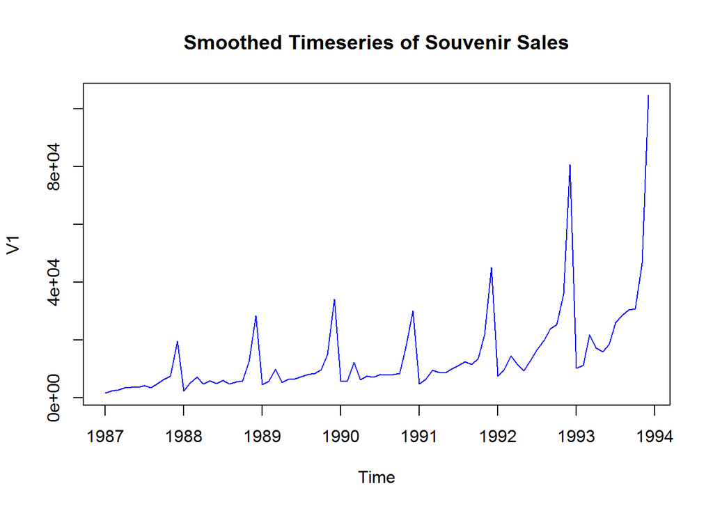

```r
#Plot time series for given data
plot.ts(souvenir.data.ts,main = "Smoothed Timeseries of Souvenir Sales", col = "blue")
```

Merge this prediction with given data and plot the entire period.

```r
#Merge the predictions with actual data
str(mergedts <- c(souvenir.data.ts,predicted.ts))
```

```
##  num [1:144] 1665 2398 2841 3547 3753 ...
```

```r
mergedts
```

```
##   [1]   1664.81   2397.53   2840.71   3547.29   3752.96   3714.74   4349.61
##   [8]   3566.34   5021.82   6423.48   7600.60  19756.21   2499.81   5198.24
##  [15]   7225.14   4806.03   5900.88   4951.34   6179.12   4752.15   5496.43
##  [22]   5835.10  12600.08  28541.72   4717.02   5702.63   9957.58   5304.78
##  [29]   6492.43   6630.80   7349.62   8176.62   8573.17   9690.50  15151.84
##  [36]  34061.01   5921.10   5814.58  12421.25   6369.77   7609.12   7224.75
##  [43]   8121.22   7979.25   8093.06   8476.70  17914.66  30114.41   4826.64
##  [50]   6470.23   9638.77   8821.17   8722.37  10209.48  11276.55  12552.22
##  [57]  11637.39  13606.89  21822.11  45060.69   7615.03   9849.69  14558.40
##  [64]  11587.33   9332.56  13082.09  16732.78  19888.61  23933.38  25391.35
##  [71]  36024.80  80721.71  10243.24  11266.88  21826.84  17357.33  15997.79
##  [78]  18601.53  26155.15  28586.52  30505.41  30821.33  46634.38 104660.67
##  [85]  14721.47  18597.48  35509.00  28420.52  26032.48  32068.58  42798.06
##  [92]  45152.26  46294.66  45625.85  67788.72 149800.86  21091.39  26644.54
##  [99]  50873.62  40717.98  37296.64  45944.53  61316.62  64689.48  66326.19
## [106]  65367.99  97120.65 214619.15  30217.57  38173.53  72886.45  58336.51
## [113]  53434.77  65824.57  87848.10  92680.39  95025.29  93652.48 139144.40
## [120] 307484.08  43292.60  54691.08 104424.16  83578.50  76555.80  94306.62
## [127] 125859.66 132782.85 136142.39 134175.58 199351.68 440531.32  62025.15
## [134]  78355.72 149608.11 119742.61 109681.21 135112.75 180318.67 190237.51
## [141] 195050.70 192232.86 285610.43 631147.63
```

```r
#Get all data(actual and predicted) in to one time series object
souvenir.data.all.ts <- ts(mergedts,start = c(1987,1),end = c(1998,12),frequency = 12)

#Write to csv
write.csv(souvenir.data.all.ts,file = "SouvenirSales_HoltsWinter.csv")
```

```r
#Check the class and plot the time series
class(souvenir.data.all.ts)
```

```
## [1] "ts"
```

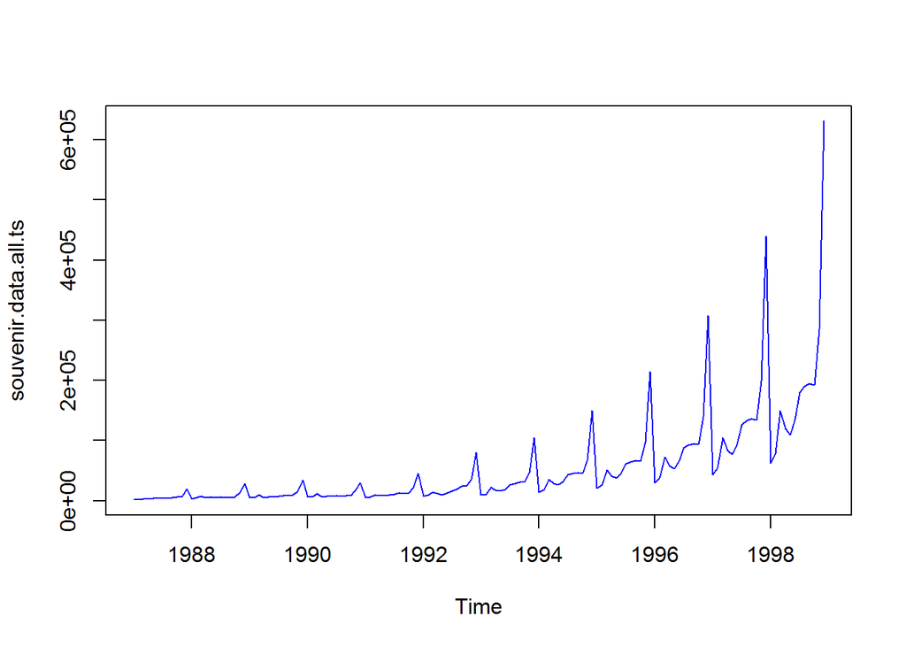

```r
plot(souvenir.data.all.ts,col = "blue" ,pch=20)
```

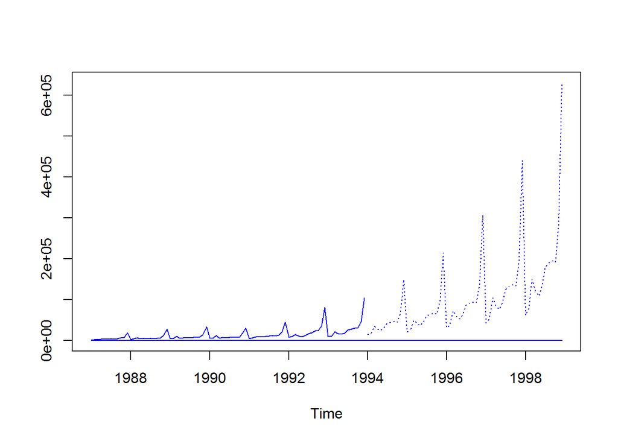

```r
ts.plot(souvenir.data.ts,predicted.ts, lty = c(1,3),col = "blue" ,pch=20)
```

## ARIMA Model

Use log function for making data stationary and then plot ACF and PACF graphs.

```r
#Use log function for making data stationary and build ARIMA model
salesLog <- log(souvenir.data.ts)
salesLog
```

```
##            Jan       Feb       Mar       Apr       May       Jun       Jul
## 1987  7.417466  7.782194  7.951809  8.173939  8.230300  8.220064  8.377841
## 1988  7.823970  8.556075  8.885322  8.477627  8.682857  8.507414  8.728931
## 1989  8.458933  8.648683  9.206089  8.576364  8.778392  8.799481  8.902404
## 1990  8.686278  8.668124  9.427164  8.759319  8.937103  8.885268  9.002236
## 1991  8.481906  8.774967  9.173549  9.084910  9.073646  9.231072  9.330481
## 1992  8.937879  9.195195  9.585923  9.357668  9.141265  9.478999  9.725125
## 1993  9.234373  9.329623  9.990896  9.761770  9.680206  9.830999 10.171801
##            Aug       Sep       Oct       Nov       Dec
## 1987  8.179295  8.521548  8.767715  8.935982  9.891223
## 1988  8.466352  8.611854  8.671647  9.441458 10.259122
## 1989  9.009034  9.056393  9.178901  9.625877 10.435909
## 1990  8.984600  8.998762  9.045077  9.793375 10.312759
## 1991  9.437653  9.361978  9.518332  9.990679 10.715766
## 1992  9.897902 10.083029 10.142164 10.491963 11.298763
## 1993 10.260691 10.325659 10.335962 10.750093 11.558479
```

[figure not shown]

```r
#Plot ACF
acf(salesLog)
```

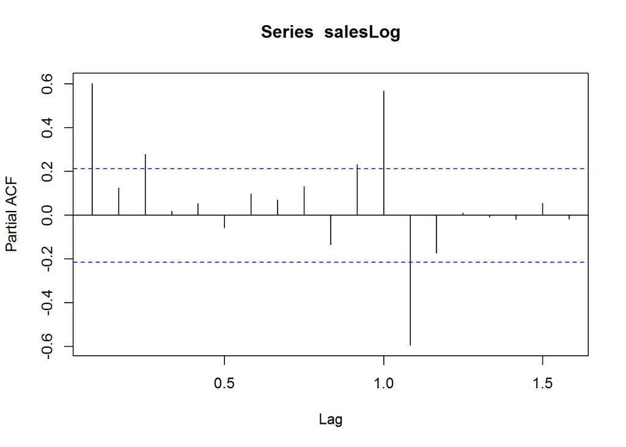

```r
#Plot PACF
pacf(salesLog)
```

Can take the values of p,d,q as 3,1,1 from ACF and PACF graphs.

Build ARIMA model with above values and check the accuracy of the forecast.

```r
#Build ARIMA modeland forecast for next 5years with the sales log
fitlog = arima(salesLog, order=c(3,1,1))
next5YearSalesFcLogArima <- forecast(fitlog, h=60)
next5YearSalesFcLogArima
```

```
##          Point Forecast     Lo 80    Hi 80    Lo 95    Hi 95
## Jan 1994       10.78455 10.108595 11.46050 9.750766 11.81833
## Feb 1994       10.53925  9.796808 11.28169 9.403784 11.67471
## Mar 1994       10.74740  9.997104 11.49769 9.599924 11.89487
## Apr 1994       10.68657  9.897941 11.47521 9.480465 11.89268
## May 1994       10.59104  9.767992 11.41409 9.332295 11.84979
## Jun 1994       10.61551  9.774184 11.45683 9.328816 11.90219
## Jul 1994       10.62416  9.762598 11.48572 9.306514 11.94180
## Aug 1994       10.60400  9.720364 11.48763 9.252597 11.95539
## Sep 1994       10.60214  9.699275 11.50500 9.221329 11.98295
## Oct 1994       10.60633  9.685087 11.52757 9.197413 12.01524
## Nov 1994       10.60374  9.663876 11.54361 9.166341 12.04114
## Dec 1994       10.60206  9.644124 11.56000 9.137022 12.06710
## Jan 1995       10.60282  9.627366 11.57827 9.110992 12.09465
## Feb 1995       10.60276  9.610017 11.59550 9.084491 12.12103
## Mar 1995       10.60230  9.592546 11.61205 9.058015 12.14659
## Apr 1995       10.60234  9.575901 11.62877 9.032539 12.17213
## May 1995       10.60240  9.559552 11.64525 9.007502 12.19730
## Jun 1995       10.60232  9.543304 11.66134 8.982693 12.22195
## Jul 1995       10.60230  9.527360 11.67724 8.958322 12.24628
## Aug 1995       10.60232  9.511694 11.69294 8.934352 12.27028
## Sep 1995       10.60231  9.496222 11.70840 8.910694 12.29393
## Oct 1995       10.60230  9.480962 11.72364 8.887361 12.31724
## Nov 1995       10.60230  9.465919 11.73869 8.864353 12.34025
## Dec 1995       10.60230  9.451070 11.75354 8.841645 12.36296
## Jan 1996       10.60230  9.436409 11.76819 8.819222 12.38538
## Feb 1996       10.60230  9.421931 11.78267 8.797080 12.40752
## Mar 1996       10.60230  9.407629 11.79697 8.775207 12.42940
## Apr 1996       10.60230  9.393496 11.81111 8.753593 12.45101
## May 1996       10.60230  9.379526 11.82508 8.732228 12.47237
## Jun 1996       10.60230  9.365714 11.83889 8.711104 12.49350
## Jul 1996       10.60230  9.352055 11.85255 8.690214 12.51439
## Aug 1996       10.60230  9.338543 11.86606 8.669550 12.53505
## Sep 1996       10.60230  9.325174 11.87943 8.649104 12.55550
## Oct 1996       10.60230  9.311944 11.89266 8.628871 12.57573
## Nov 1996       10.60230  9.298848 11.90575 8.608842 12.59576
## Dec 1996       10.60230  9.285883 11.91872 8.589013 12.61559
## Jan 1997       10.60230  9.273043 11.93156 8.569377 12.63523
## Feb 1997       10.60230  9.260327 11.94428 8.549929 12.65467
## Mar 1997       10.60230  9.247730 11.95687 8.530664 12.67394
## Apr 1997       10.60230  9.235249 11.96935 8.511576 12.69303
## May 1997       10.60230  9.222881 11.98172 8.492661 12.71194
## Jun 1997       10.60230  9.210623 11.99398 8.473913 12.73069
## Jul 1997       10.60230  9.198472 12.00613 8.455330 12.74927
## Aug 1997       10.60230  9.186425 12.01818 8.436906 12.76770
## Sep 1997       10.60230  9.174480 12.03012 8.418638 12.78596
## Oct 1997       10.60230  9.162634 12.04197 8.400521 12.80408
## Nov 1997       10.60230  9.150885 12.05372 8.382552 12.82205
## Dec 1997       10.60230  9.139230 12.06537 8.364727 12.83988
## Jan 1998       10.60230  9.127667 12.07694 8.347043 12.85756
## Feb 1998       10.60230  9.116194 12.08841 8.329497 12.87511
## Mar 1998       10.60230  9.104809 12.09979 8.312085 12.89252
## Apr 1998       10.60230  9.093510 12.11109 8.294804 12.90980
## May 1998       10.60230  9.082295 12.12231 8.277652 12.92695
## Jun 1998       10.60230  9.071162 12.13344 8.260626 12.94398
## Jul 1998       10.60230  9.060109 12.14449 8.243722 12.96088
## Aug 1998       10.60230  9.049135 12.15547 8.226939 12.97766
## Sep 1998       10.60230  9.038238 12.16636 8.210274 12.99433
## Oct 1998       10.60230  9.027417 12.17719 8.193724 13.01088
## Nov 1998       10.60230  9.016669 12.18793 8.177286 13.02732
## Dec 1998       10.60230  9.005994 12.19861 8.160960 13.04364
```

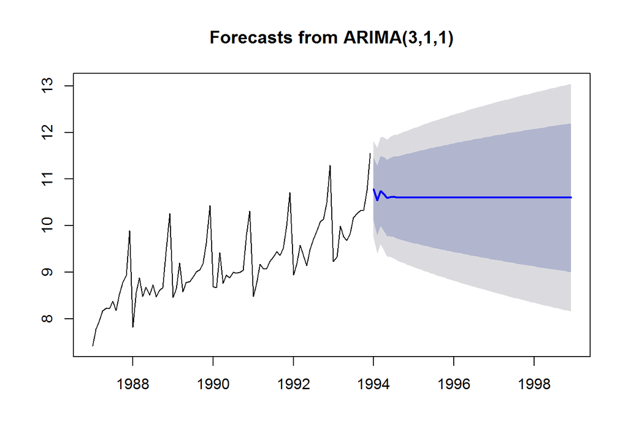

```r
plot(next5YearSalesFcLogArima)
```

```r
accuracy(next5YearSalesFcLogArima)
```

```
##                     ME      RMSE       MAE      MPE     MAPE     MASE
## Training set 0.1294279 0.5243016 0.3705145 1.168754 3.943575 1.182107
##                     ACF1
## Training set -0.04614592
```

MAPE for this model is 3.94

Get seasonally adjusted data constructed by removing the seasonal component and build ARIMA with same p,d,q as 3,1,1

```r
#Get seasonally adjusted data constructed by removing the seasonal component
deseasonal_cnt <- seasadj(souvenir.data.ts.decompM)

#Build ARIMA modeland forecast for next 12 months
fit = arima(deseasonal_cnt, order=c(3,1,1))
fcast <- forecast(fit, h=60)
fcast
```

```
##          Point Forecast    Lo 80    Hi 80     Lo 95    Hi 95
## Jan 1994       32830.72 30139.69 35521.76 28715.141 36946.30
## Feb 1994       33126.84 29528.51 36725.17 27623.669 38630.01
## Mar 1994       32983.32 28530.71 37435.93 26173.646 39793.00
## Apr 1994       33006.59 27983.29 38029.89 25324.114 40689.06
## May 1994       32955.84 27458.08 38453.60 24547.742 41363.94
## Jun 1994       32950.89 27064.36 38837.42 23948.214 41953.56
## Jul 1994       32937.06 26701.17 39172.95 23400.088 42474.03
## Aug 1994       32935.67 26379.20 39492.13 22908.419 42962.92
## Sep 1994       32933.49 26073.49 39793.50 22442.018 43424.97
## Oct 1994       32934.02 25784.03 40084.01 21999.052 43868.98
## Nov 1994       32934.19 25504.92 40363.46 21572.096 44296.28
## Dec 1994       32934.68 25235.74 40633.61 21160.170 44709.18
## Jan 1995       32934.91 24974.98 40894.83 20761.255 45108.56
## Feb 1995       32935.09 24722.22 41147.95 20374.596 45495.58
## Mar 1995       32935.16 24476.78 41393.53 19999.183 45871.13
## Apr 1995       32935.19 24238.17 41632.20 19634.254 46236.12
## May 1995       32935.19 24005.90 41864.48 19279.023 46591.36
## Jun 1995       32935.19 23779.52 42090.86 18932.798 46937.58
## Jul 1995       32935.18 23558.60 42311.77 18594.935 47275.43
## Aug 1995       32935.18 23342.77 42527.58 18264.862 47605.50
## Sep 1995       32935.18 23131.70 42738.65 17942.059 47928.29
## Oct 1995       32935.17 22925.09 42945.26 17626.067 48244.28
## Nov 1995       32935.17 22722.65 43147.70 17316.468 48553.88
## Dec 1995       32935.17 22524.15 43346.20 17012.889 48857.46
## Jan 1996       32935.17 22329.37 43540.98 16714.991 49155.36
## Feb 1996       32935.17 22138.09 43732.25 16422.466 49447.88
## Mar 1996       32935.17 21950.15 43920.20 16135.034 49735.31
## Apr 1996       32935.17 21765.37 44104.98 15852.438 50017.91
## May 1996       32935.17 21583.60 44286.75 15574.440 50295.91
## Jun 1996       32935.17 21404.69 44465.66 15300.825 50569.52
## Jul 1996       32935.17 21228.52 44641.83 15031.391 50838.96
## Aug 1996       32935.17 21054.96 44815.39 14765.952 51104.40
## Sep 1996       32935.17 20883.90 44986.45 14504.335 51366.01
## Oct 1996       32935.17 20715.23 45155.12 14246.380 51623.97
## Nov 1996       32935.17 20548.86 45321.49 13991.938 51878.41
## Dec 1996       32935.17 20384.69 45485.66 13740.868 52129.48
## Jan 1997       32935.17 20222.65 45647.70 13493.040 52377.31
## Feb 1997       32935.17 20062.64 45807.71 13248.332 52622.02
## Mar 1997       32935.17 19904.60 45965.75 13006.628 52863.72
## Apr 1997       32935.17 19748.45 46121.90 12767.821 53102.53
## May 1997       32935.17 19594.13 46276.22 12531.808 53338.54
## Jun 1997       32935.17 19441.57 46428.77 12298.495 53571.85
## Jul 1997       32935.17 19290.73 46579.62 12067.790 53802.56
## Aug 1997       32935.17 19141.53 46728.82 11839.608 54030.74
## Sep 1997       32935.17 18993.92 46876.43 11613.868 54256.48
## Oct 1997       32935.17 18847.86 47022.48 11390.493 54479.86
## Nov 1997       32935.17 18703.31 47167.04 11169.411 54700.94
## Dec 1997       32935.17 18560.20 47310.15 10950.551 54919.80
## Jan 1998       32935.17 18418.51 47451.84 10733.849 55136.50
## Feb 1998       32935.17 18278.18 47592.16 10519.242 55351.11
## Mar 1998       32935.17 18139.19 47731.16 10306.670 55563.68
## Apr 1998       32935.17 18001.49 47868.86 10096.076 55774.27
## May 1998       32935.17 17865.05 48005.30  9887.406 55982.94
## Jun 1998       32935.17 17729.83 48140.52  9680.609 56189.74
## Jul 1998       32935.17 17595.81 48274.54  9475.635 56394.71
## Aug 1998       32935.17 17462.94 48407.41  9272.436 56597.91
## Sep 1998       32935.17 17331.21 48539.14  9070.968 56799.38
## Oct 1998       32935.17 17200.58 48669.77  8871.186 56999.16
## Nov 1998       32935.17 17071.02 48799.33  8673.049 57197.30
## Dec 1998       32935.17 16942.52 48927.83  8476.517 57393.83
```

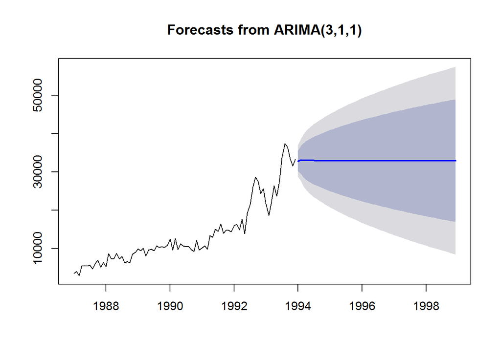

```r
plot(fcast)
```

```r
accuracy(fcast)
```

```
##                    ME     RMSE      MAE      MPE     MAPE      MASE        ACF1
## Training set 464.8358 2087.289 1570.205 2.017194 12.13805 0.3736439 -0.06312392
```

MAPE for this model is 12.13

Use auto.arima with seasonal as false to get the best non seasonal model.

```r
#Use auto.arima to get the best model
#Use auto.arima with seasonal as false to get the best non seasonal model
fit_nonseasonal<-auto.arima(deseasonal_cnt, seasonal=FALSE)
fcast_nonseasonal <- forecast(fit_nonseasonal, h=60)
fcast_nonseasonal
```

```
##          Point Forecast    Lo 80    Hi 80    Lo 95    Hi 95
## Jan 1994       33612.41 30894.27 36330.55 29455.37 37769.44
## Feb 1994       33970.79 30126.76 37814.82 28091.85 39849.73
## Mar 1994       34329.17 29621.22 39037.13 27128.98 41529.37
## Apr 1994       34687.56 29251.28 40123.84 26373.49 43001.63
## May 1994       35045.94 28967.99 41123.88 25750.52 44341.35
## Jun 1994       35404.32 28746.27 42062.38 25221.71 45586.94
## Jul 1994       35762.71 28571.18 42954.23 24764.22 46761.19
## Aug 1994       36121.09 28433.03 43809.15 24363.22 47878.96
## Sep 1994       36479.47 28325.05 44633.89 24008.36 48950.58
## Oct 1994       36837.85 28242.34 45433.37 23692.15 49983.56
## Nov 1994       37196.24 28181.19 46211.29 23408.91 50983.56
## Dec 1994       37554.62 28138.71 46970.53 23154.22 51955.01
## Jan 1995       37913.00 28112.61 47713.39 22924.60 52901.41
## Feb 1995       38271.39 28101.04 48441.73 22717.18 53825.59
## Mar 1995       38629.77 28102.46 49157.08 22529.64 54729.90
## Apr 1995       38988.15 28115.59 49860.71 22360.01 55616.29
## May 1995       39346.53 28139.36 50553.71 22206.64 56486.43
## Jun 1995       39704.92 28172.83 51237.01 22068.11 57341.73
## Jul 1995       40063.30 28215.20 51911.40 21943.20 58183.40
## Aug 1995       40421.68 28265.79 52577.57 21830.85 59012.51
## Sep 1995       40780.07 28323.98 53236.15 21730.13 59830.00
## Oct 1995       41138.45 28389.24 53887.65 21640.22 60636.67
## Nov 1995       41496.83 28461.09 54532.57 21560.39 61433.27
## Dec 1995       41855.21 28539.10 55171.32 21489.98 62220.45
## Jan 1996       42213.60 28622.90 55804.29 21428.42 62998.78
## Feb 1996       42571.98 28712.13 56431.83 21375.17 63768.79
## Mar 1996       42930.36 28806.49 57054.23 21329.77 64530.95
## Apr 1996       43288.75 28905.70 57671.79 21291.78 65285.71
## May 1996       43647.13 29009.50 58284.76 21260.80 66033.45
## Jun 1996       44005.51 29117.65 58893.37 21236.49 66774.53
## Jul 1996       44363.89 29229.93 59497.85 21218.50 67509.29
## Aug 1996       44722.28 29346.16 60098.40 21206.53 68238.02
## Sep 1996       45080.66 29466.14 60695.18 21200.31 68961.01
## Oct 1996       45439.04 29589.70 61288.38 21199.57 69678.52
## Nov 1996       45797.43 29716.69 61878.16 21204.07 70390.78
## Dec 1996       46155.81 29846.97 62464.65 21213.59 71098.02
## Jan 1997       46514.19 29980.39 63047.99 21227.93 71800.45
## Feb 1997       46872.57 30116.84 63628.31 21246.88 72498.26
## Mar 1997       47230.96 30256.18 64205.73 21270.28 73191.64
## Apr 1997       47589.34 30398.31 64780.36 21297.94 73880.74
## May 1997       47947.72 30543.14 65352.31 21329.70 74565.74
## Jun 1997       48306.10 30690.55 65921.66 21365.43 75246.78
## Jul 1997       48664.49 30840.45 66488.52 21404.98 75924.00
## Aug 1997       49022.87 30992.77 67052.97 21448.21 76597.53
## Sep 1997       49381.25 31147.42 67615.09 21495.01 77267.50
## Oct 1997       49739.64 31304.32 68174.96 21545.25 77934.03
## Nov 1997       50098.02 31463.39 68732.65 21598.82 78597.22
## Dec 1997       50456.40 31624.58 69288.23 21655.61 79257.19
## Jan 1998       50814.78 31787.81 69841.76 21715.53 79914.04
## Feb 1998       51173.17 31953.02 70393.32 21778.49 80567.85
## Mar 1998       51531.55 32120.15 70942.95 21844.38 81218.72
## Apr 1998       51889.93 32289.15 71490.72 21913.12 81866.75
## May 1998       52248.32 32459.96 72036.67 21984.64 82511.99
## Jun 1998       52606.70 32632.53 72580.86 22058.85 83154.55
## Jul 1998       52965.08 32806.82 73123.35 22135.68 83794.49
## Aug 1998       53323.46 32982.77 73664.16 22215.06 84431.87
## Sep 1998       53681.85 33160.34 74203.35 22296.92 85066.78
## Oct 1998       54040.23 33339.50 74740.97 22381.19 85699.27
## Nov 1998       54398.61 33520.19 75277.04 22467.81 86329.41
## Dec 1998       54757.00 33702.38 75811.62 22556.73 86957.26
```

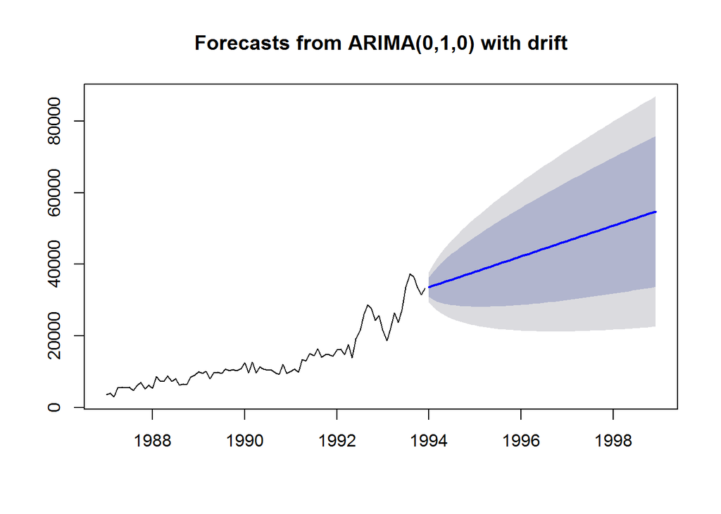

```r
#Plot the forecast
plot(fcast_nonseasonal)
```

```r
#Check accuracy
accuracy(fcast_nonseasonal)
```

```
##                      ME     RMSE     MAE       MPE     MAPE      MASE
## Training set 0.03749839 2095.574 1631.55 -2.234928 13.15192 0.3882416
##                    ACF1
## Training set -0.1500211
```

MAPE for this model is 13.15

Use auto.arima with seasonal as true to get the best seasonal model.

```r
#Use auto.arima with seasonal as true to get the best seasonal model
fit_seasonal = auto.arima(deseasonal_cnt, seasonal=TRUE)
fcast_seasonal <- forecast(fit_seasonal, h=60)
fcast_seasonal
```

```
##          Point Forecast     Lo 80    Hi 80       Lo 95    Hi 95
## Jan 1994       31417.11 28828.669 34005.55 27458.43028 35375.79
## Feb 1994       30315.58 26654.969 33976.19 24717.15988 35914.00
## Mar 1994       31815.28 27331.967 36298.59 24958.64537 38671.91
## Apr 1994       33296.33 28119.445 38473.21 25378.96980 41213.68
## May 1994       32757.79 26969.865 38545.72 23905.91974 41609.67
## Jun 1994       33510.72 27170.364 39851.08 23813.98120 43207.47
## Jul 1994       35569.19 28720.817 42417.56 25095.50872 46042.87
## Aug 1994       36476.63 29155.412 43797.84 25279.79439 47673.46
## Sep 1994       35606.11 27840.792 43371.44 23730.07872 47482.15
## Oct 1994       34642.19 26456.826 42827.56 22123.75391 47160.63
## Nov 1994       34298.63 25713.746 42883.52 21169.18149 47428.08
## Dec 1994       34816.10 25849.475 43782.72 21102.83260 48529.36
## Jan 1995       34816.10 25154.946 44477.25 20040.64172 49591.55
## Feb 1995       34816.10 24507.102 45125.09 19049.85024 50582.34
## Mar 1995       34816.10 23897.631 45734.56 18117.74394 51514.45
## Apr 1995       34816.10 23320.426 46311.77 17234.98632 52397.21
## May 1995       34816.10 22770.850 46861.34 16394.48170 53237.71
## Jun 1995       34816.10 22245.277 47386.92 15590.68756 54041.50
## Jul 1995       34816.10 21740.813 47891.38 14819.17659 54813.02
## Aug 1995       34816.10 21255.102 48377.09 14076.34571 55555.85
## Sep 1995       34816.10 20786.196 48846.00 13359.21603 56272.98
## Oct 1995       34816.10 20332.463 49299.73 12665.29118 56966.90
## Nov 1995       34816.10 19892.519 49739.67 11992.45452 57639.74
## Dec 1995       34816.10 19465.178 50167.01 11338.89287 58293.30
## Jan 1996       34816.10 19049.415 50582.78 10703.03889 58929.15
## Feb 1996       34816.10 18644.338 50987.85 10083.52680 59548.67
## Mar 1996       34816.10 18249.163 51383.03  9479.15784 60153.03
## Apr 1996       34816.10 17863.196 51769.00  8888.87302 60743.32
## May 1996       34816.10 17485.823 52146.37  8311.73131 61320.46
## Jun 1996       34816.10 17116.495 52515.70  7746.89202 61885.30
## Jul 1996       34816.10 16754.717 52877.48  7193.60045 62438.59
## Aug 1996       34816.10 16400.045 53232.15  6651.17604 62981.02
## Sep 1996       34816.10 16052.075 53580.12  6119.00255 63513.19
## Oct 1996       34816.10 15710.442 53921.75  5596.51987 64035.67
## Nov 1996       34816.10 15374.812 54257.38  5083.21714 64548.98
## Dec 1996       34816.10 15044.878 54587.31  4578.62684 65053.57
## Jan 1997       34816.10 14720.360 54911.83  4082.31983 65549.87
## Feb 1997       34816.10 14401.000 55231.19  3593.90111 66038.29
## Mar 1997       34816.10 14086.560 55545.63  3113.00608 66519.19
## Apr 1997       34816.10 13776.818 55855.37  2639.29743 66992.89
## May 1997       34816.10 13471.571 56160.62  2172.46228 67459.73
## Jun 1997       34816.10 13170.628 56461.56  1712.20984 67919.98
## Jul 1997       34816.10 12873.813 56758.38  1258.26926 68373.92
## Aug 1997       34816.10 12580.959 57051.23   810.38778 68821.80
## Sep 1997       34816.10 12291.912 57340.28   368.32905 69263.86
## Oct 1997       34816.10 12006.528 57625.66   -68.12829 69700.32
## Nov 1997       34816.10 11724.670 57907.52  -499.19191 70131.38
## Dec 1997       34816.10 11446.212 58185.98  -925.05698 70557.25
## Jan 1998       34816.10 11171.033 58461.16 -1345.90716 70978.10
## Feb 1998       34816.10 10899.020 58733.17 -1761.91555 71394.11
## Mar 1998       34816.10 10630.066 59002.13 -2173.24551 71805.44
## Apr 1998       34816.10 10364.070 59268.12 -2580.05142 72212.24
## May 1998       34816.10 10100.936 59531.26 -2982.47934 72614.67
## Jun 1998       34816.10  9840.575 59791.62 -3380.66766 73012.86
## Jul 1998       34816.10  9582.900 60049.29 -3774.74761 73406.94
## Aug 1998       34816.10  9327.830 60304.36 -4164.84379 73797.04
## Sep 1998       34816.10  9075.287 60556.91 -4551.07463 74183.27
## Oct 1998       34816.10  8825.198 60806.99 -4933.55280 74565.75
## Nov 1998       34816.10  8577.492 61054.70 -5312.38560 74944.58
## Dec 1998       34816.10  8332.104 61300.09 -5687.67533 75319.87
```

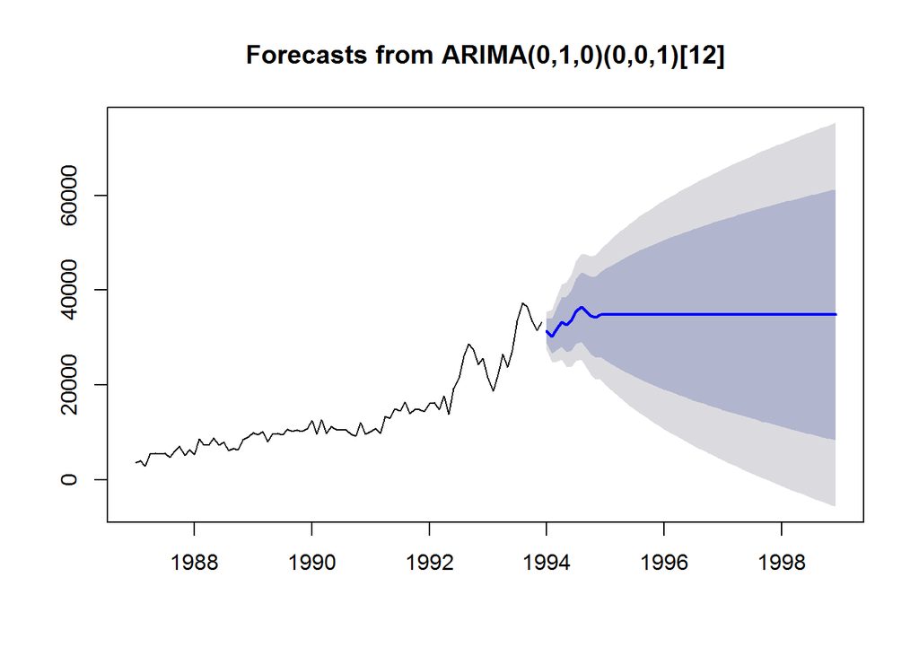

```r
#Plot the forecast
plot(fcast_seasonal)
```

```r
#Check accuracy
accuracy(fcast_seasonal)
```

```
##                    ME     RMSE      MAE       MPE     MAPE      MASE       ACF1
## Training set 267.3865 1995.581 1596.243 0.7555043 12.92443 0.3798399 -0.1655936
```

Compare the above forecasts. And decide which model to use based on accuracy.

MAPE for next5YearSalesFcLogArima: 3.94 MAPE for fcast: 12.13 MAPE for fcast_nonseasonal: 13.15 MAPE for fcast_seasonal: 12.92

First method has given better accuracy. So, let us use this forecast. However, the forecast has been done on log so they have to be converted to real values to get actual numbers for next 5 years.

```r
#The forecasted values of souviner sales for the next five years
#The values are calculated at 80% and 95% confidence interval.
write.csv(next5YearSalesFcLogArima,file = "Next5YearsForecast_Arima_Log.csv")
logPredArima <- read.csv("Next5YearsForecast_Arima_Log.csv",header = TRUE)

#Get the real value by applying antilog.
#log function in R is natural logarithm with base e.
#So use exp function to get e power of value
realPredArima <- exp(logPredArima[2])
realPredArima
```

```
##    Point.Forecast
## 1        48269.21
## 2        37769.18
## 3        46508.77
## 4        43764.29
## 5        39776.95
## 6        40761.98
## 7        41116.28
## 8        40295.50
## 9        40220.71
## 10       40389.54
## 11       40285.24
## 12       40217.64
## 13       40248.15
## 14       40245.77
```

[output cut: 46 more lines]

```r
class(realPredArima)
```

```
## [1] "data.frame"
```

```r
# Bind the prediictions column
next5years_prediction_Arima <- cbind(logPredArima,realPredArima)

#Name the last column filled with predictions
names(next5years_prediction_Arima)[7]<-"Predicted Value"

#See the predictions
next5years_prediction_Arima
```

```
##           X Point.Forecast     Lo.80    Hi.80    Lo.95    Hi.95 Predicted Value
## 1  Jan 1994       10.78455 10.108595 11.46050 9.750766 11.81833        48269.21
## 2  Feb 1994       10.53925  9.796808 11.28169 9.403784 11.67471        37769.18
## 3  Mar 1994       10.74740  9.997104 11.49769 9.599924 11.89487        46508.77
## 4  Apr 1994       10.68657  9.897941 11.47521 9.480465 11.89268        43764.29
## 5  May 1994       10.59104  9.767992 11.41409 9.332295 11.84979        39776.95
## 6  Jun 1994       10.61551  9.774184 11.45683 9.328816 11.90219        40761.98
## 7  Jul 1994       10.62416  9.762598 11.48572 9.306514 11.94180        41116.28
## 8  Aug 1994       10.60400  9.720364 11.48763 9.252597 11.95539        40295.50
## 9  Sep 1994       10.60214  9.699275 11.50500 9.221329 11.98295        40220.71
## 10 Oct 1994       10.60633  9.685087 11.52757 9.197413 12.01524        40389.54
## 11 Nov 1994       10.60374  9.663876 11.54361 9.166341 12.04114        40285.24
## 12 Dec 1994       10.60206  9.644124 11.56000 9.137022 12.06710        40217.64
## 13 Jan 1995       10.60282  9.627366 11.57827 9.110992 12.09465        40248.15
## 14 Feb 1995       10.60276  9.610017 11.59550 9.084491 12.12103        40245.77
```

[output cut: 46 more lines]

```r
#The forecasted values of souviner sales for the next five years
#The values are calculated at 80% and 95% confidence interval.
write.csv(next5years_prediction_Arima,file = "Next5YearsForecast_Arima.csv")
class(next5years_prediction_Arima)
```

```
## [1] "data.frame"
```

Convert the predicted values to time series and plot the series.

```r
#Get the predicted values as time series object
predicted.ts.Arima <- ts(realPredArima,start = c(1994,1),end = c(1998,12),frequency = 12)

#Check the object
class(predicted.ts.Arima)
```

```
## [1] "ts"
```

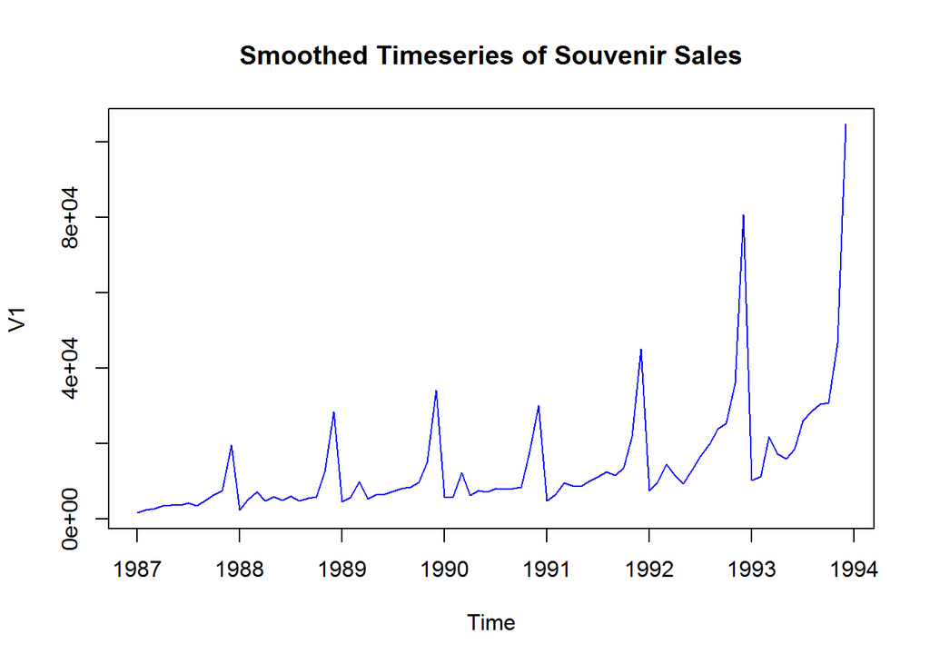

```r
#Plot time series for given data
plot.ts(souvenir.data.ts,main = "Smoothed Timeseries of Souvenir Sales", col = "blue")
```

```r
#Merge the predictions with actual data
str(mergedtsArima <- c(souvenir.data.ts,predicted.ts.Arima))
```

```
##  num [1:144] 1665 2398 2841 3547 3753 ...
```

```r
mergedtsArima
```

```
##   [1]   1664.81   2397.53   2840.71   3547.29   3752.96   3714.74   4349.61
##   [8]   3566.34   5021.82   6423.48   7600.60  19756.21   2499.81   5198.24
##  [15]   7225.14   4806.03   5900.88   4951.34   6179.12   4752.15   5496.43
##  [22]   5835.10  12600.08  28541.72   4717.02   5702.63   9957.58   5304.78
##  [29]   6492.43   6630.80   7349.62   8176.62   8573.17   9690.50  15151.84
##  [36]  34061.01   5921.10   5814.58  12421.25   6369.77   7609.12   7224.75
##  [43]   8121.22   7979.25   8093.06   8476.70  17914.66  30114.41   4826.64
##  [50]   6470.23   9638.77   8821.17   8722.37  10209.48  11276.55  12552.22
##  [57]  11637.39  13606.89  21822.11  45060.69   7615.03   9849.69  14558.40
##  [64]  11587.33   9332.56  13082.09  16732.78  19888.61  23933.38  25391.35
##  [71]  36024.80  80721.71  10243.24  11266.88  21826.84  17357.33  15997.79
##  [78]  18601.53  26155.15  28586.52  30505.41  30821.33  46634.38 104660.67
##  [85]  48269.21  37769.18  46508.77  43764.29  39776.95  40761.98  41116.28
##  [92]  40295.50  40220.71  40389.54  40285.24  40217.64  40248.15  40245.77
##  [99]  40227.27  40228.68  40231.32  40228.17  40227.21  40227.94  40227.66
## [106]  40227.28  40227.37  40227.39  40227.31  40227.30  40227.32  40227.30
## [113]  40227.30  40227.30  40227.30  40227.30  40227.30  40227.30  40227.30
## [120]  40227.30  40227.30  40227.30  40227.30  40227.30  40227.30  40227.30
## [127]  40227.30  40227.30  40227.30  40227.30  40227.30  40227.30  40227.30
## [134]  40227.30  40227.30  40227.30  40227.30  40227.30  40227.30  40227.30
## [141]  40227.30  40227.30  40227.30  40227.30
```

```r
#Get all data(actual and predicted) in to one time series object
souvenir.data.all.ts.Arima <- ts(mergedtsArima,start = c(1987,1),end = c(1998,12),frequency = 12)

#Write to csv
write.csv(souvenir.data.all.ts.Arima,file = "SouvenirSales_Arima.csv")

#Check the class and plot the time series
class(souvenir.data.all.ts.Arima)
```

```
## [1] "ts"
```

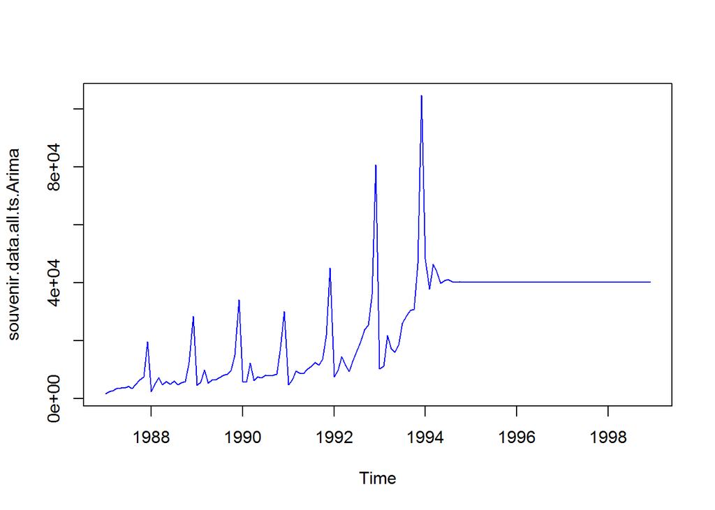

```r
plot(souvenir.data.all.ts.Arima,col = "blue" ,pch=20)
```

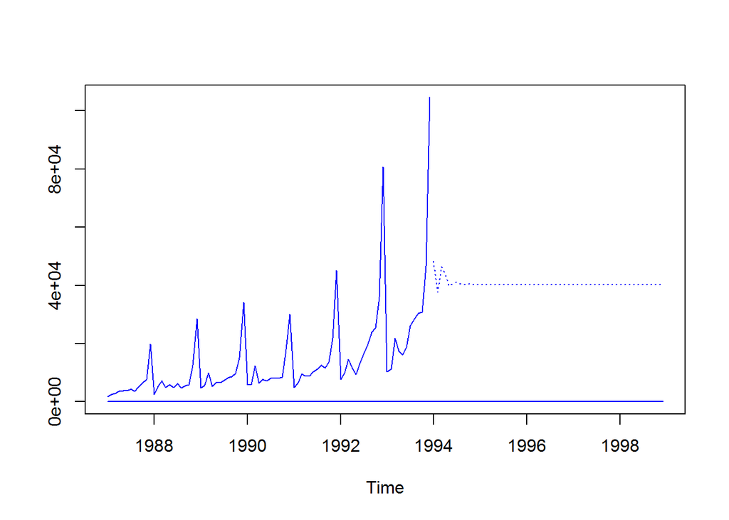

```r
ts.plot(souvenir.data.ts,predicted.ts.Arima, lty = c(1,3),col = "blue" ,pch=20)
```

## Compare and conclude

**Sales forecast using Holts-Winter**

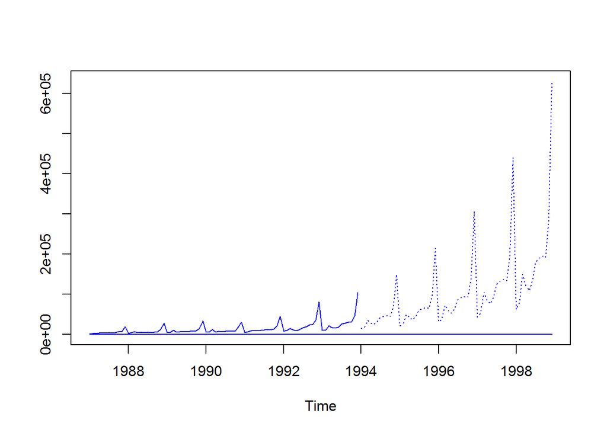

```r
ts.plot(souvenir.data.ts,predicted.ts, lty = c(1,3),col = "blue" ,pch=20)
```

```r
accuracy(next5YearSalesFcLogHW)
```

```
##                        ME      RMSE       MAE         MPE     MAPE      MASE
## Training set -0.006421623 0.1671448 0.1278046 -0.08896552 1.385112 0.4077539
##                    ACF1
## Training set 0.04525314
```

**Sales forecast using ARIMA**

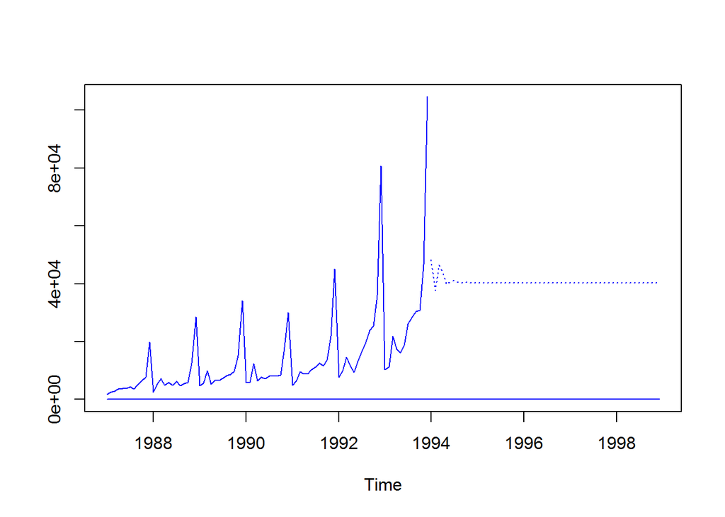

```r
ts.plot(souvenir.data.ts,predicted.ts.Arima, lty = c(1,3),col = "blue" ,pch=20)
```

```r
accuracy(next5YearSalesFcLogArima)
```

```
##                     ME      RMSE       MAE      MPE     MAPE     MASE
## Training set 0.1294279 0.5243016 0.3705145 1.168754 3.943575 1.182107
##                     ACF1
## Training set -0.04614592
```

Comparing among the models created, Holts-Winter model can be preferred as it has lesser value of error components and graphs that are believable.